# Tugas Pertemuan 5

Muhammad Fauzan Nur Rasendriya (G1401231108)

02 October 2025

# 1 Library

```r
install_load <- function (package1, ...){
   packages <- c(package1, ...)
   for(package in packages){
       if(package %in% rownames(installed.packages())){
         do.call('library', list(package))
       }
       else{
          install.packages(package)
          do.call("library", list(package))
       }
   }
}

install_load("knitr","showtext","rio","dplyr","tsibble","ggplot2","MASS","lattice","tseries")

opts_knit$set(root.dir = normalizePath("./"))

font_add_google("Lato", "lato")
showtext_auto()
```

# 2 Data

## 2.1 Impor Data

```r
data <- import("https://raw.githubusercontent.com/fauzanrasendriya/MPDW/main/Pertemuan%205/dataudarajkt.csv")

head(data)
```

|  | tanggal | stasiun | pm25 | pm10 | so2 | co | o3 | no2 | max | critical | categori |
| --- | --- | --- | --- | --- | --- | --- | --- | --- | --- | --- | --- |
| 1 | 2023-10-18 | DKI1 (Bunderan HI) | 108 | 64 | 50 | 9 | 29 | 34 | 108 | PM25 | TIDAK SEHAT |
| 2 | 2023-10-19 | DKI1 (Bunderan HI) | 93 | 65 | 51 | 9 | 25 | 30 | 93 | PM25 | SEDANG |
| 3 | 2023-10-20 | DKI1 (Bunderan HI) | 78 | 62 | 50 | 6 | 29 | 23 | 78 | PM25 | SEDANG |
| 4 | 2023-10-21 | DKI1 (Bunderan HI) | 88 | 63 | 49 | 6 | 24 | 33 | 88 | PM25 | SEDANG |
| 5 | 2023-10-22 | DKI1 (Bunderan HI) | 91 | 60 | 47 | 4 | 37 | 25 | 91 | PM25 | SEDANG |
| 6 | 2023-10-23 | DKI1 (Bunderan HI) | 86 | 62 | 48 | 6 | 37 | 27 | 86 | PM25 | SEDANG |

Data yang digunakan merupakan data kualitas udara dengan peubah yang diamati adalah PM10, yaitu konsentrasi partikel dengan diameter 10 mikrometer atau lebih kecil. Dataset aslinya mencakup periode yang lebih panjang, namun untuk analisis ini diambil 125 observasi dari tanggal 24 Juni 2024 hingga 28 Oktober 2024. Data ini diperoleh dari Kaggle.

# 3 Eksplorasi Data

```r
names(data)
```

```
##  [1] "tanggal"  "stasiun"  "pm25"     "pm10"     "so2"      "co"
##  [7] "o3"       "no2"      "max"      "critical" "categori"
```

```r
# -----------------------------
# Pilih peubah target di sini
# -----------------------------
target_col <- "pm10"
```

```r
# filter baris 251 sampai 375
subset_data <- data[251:375, c("tanggal", "stasiun", target_col)]

# lihat data
head(subset_data)
```

|  | tanggal | stasiun | pm10 |
| --- | --- | --- | --- |
| 251 | 2024-06-24 | DKI1 (Bunderan HI) | 57 |
| 252 | 2024-06-25 | DKI1 (Bunderan HI) | 58 |
| 253 | 2024-06-26 | DKI1 (Bunderan HI) | 51 |
| 254 | 2024-06-27 | DKI1 (Bunderan HI) | 56 |
| 255 | 2024-06-28 | DKI1 (Bunderan HI) | 53 |
| 256 | 2024-06-29 | DKI1 (Bunderan HI) | 52 |

## 3.1 Plot *Time Series*

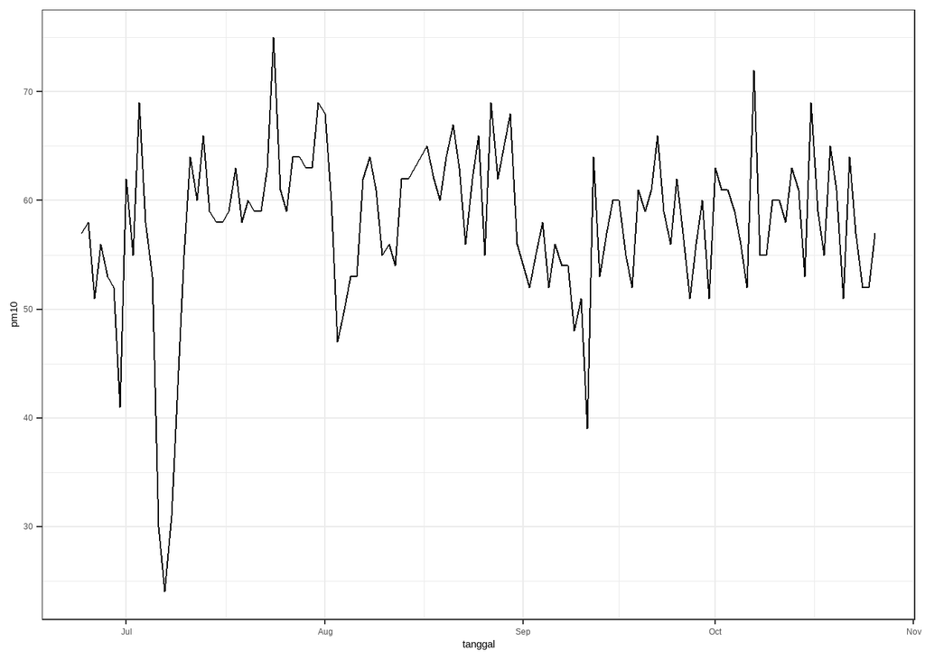

```r
plot_subset_data <- subset_data |>
  as_tsibble(index = tanggal) |>
  ggplot(aes(x = tanggal, y = subset_data[[target_col]])) +
  geom_line() +
  theme_bw() +
  xlab("tanggal") +
  ylab(target_col)

plot_subset_data
```

Berdasarkan plot *time series*, data terlihat stasioner dalam rataan karena tidak menunjukkan adanya tren maupun pola musiman. Namun, data belum stasioner dalam ragam, yang ditunjukkan oleh adanya perbedaan besar-kecilnya fluktuasi pada plot.

```r
mean(subset_data[[target_col]])
```

```
## [1] 57.84
```

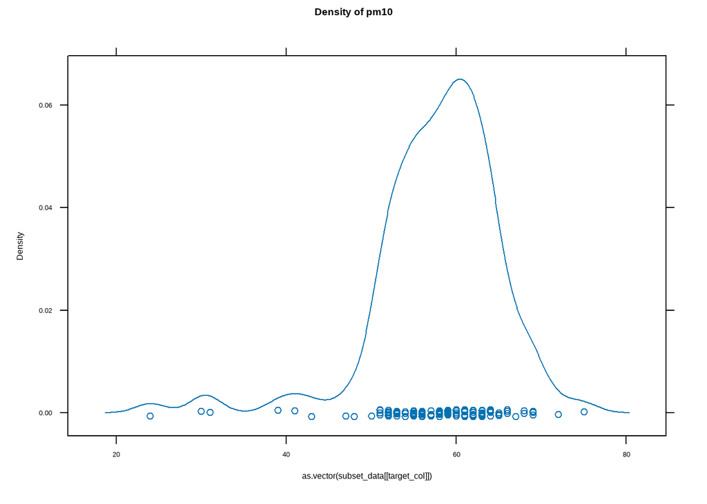

```r
lattice::densityplot(as.vector(subset_data[[target_col]]), main = paste("Density of", target_col))
```

Plot *density* di atas menunjukkan bahwa data stasioner dalam rataan, ditandai dengan data yang menyebar di nilai tengahnya (57) dan tidak stasioner dalam ragam, ditandai dengan data berfluktuasi pada rentang yang berbeda sepanjang waktu.

## 3.2 Plot ACF

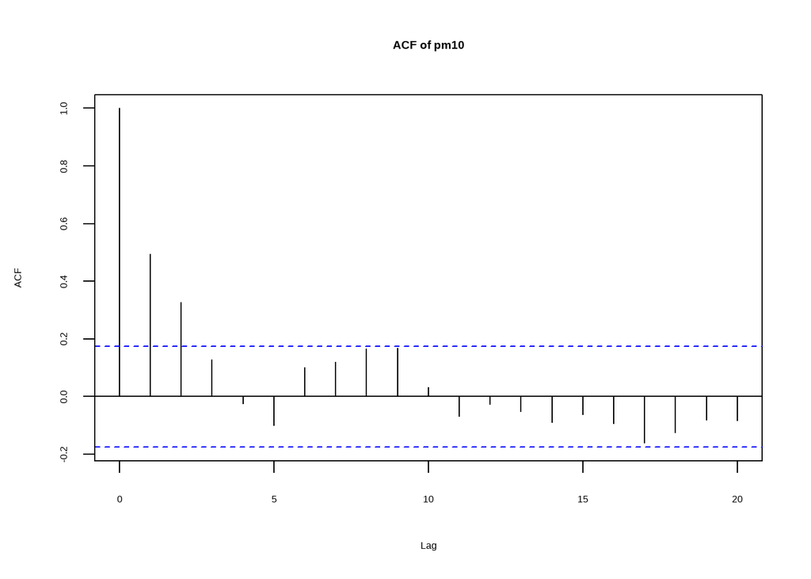

```r
acf(subset_data[[target_col]], main = paste("ACF of", target_col))
```

Berdasarkan plot ACF, terlihat bahwa plot ACF pada data tersebut cenderung tails off dan membentuk gelombang sinus.

## 3.3 Uji ADF

```r
tseries::adf.test(subset_data[[target_col]])
```

```
##
##  Augmented Dickey-Fuller Test
##
## data:  subset_data[[target_col]]
## Dickey-Fuller = -4.8018, Lag order = 4, p-value = 0.01
## alternative hypothesis: stationary
```

$H_0$ : Data tidak stasioner dalam rataan

$H_1$ : Data stasioner dalam rataan

Berdasarkan uji ADF tersebut, didapat p-value sebesar 0.01 yang kurang dari taraf nyata 5% dan menandakan bahwa data stasioner dalam rataan. Hal ini sesuai dengan hasil eksplorasi menggunakan plot time series dan plot ACF.

## 3.4 Plot Box-Cox

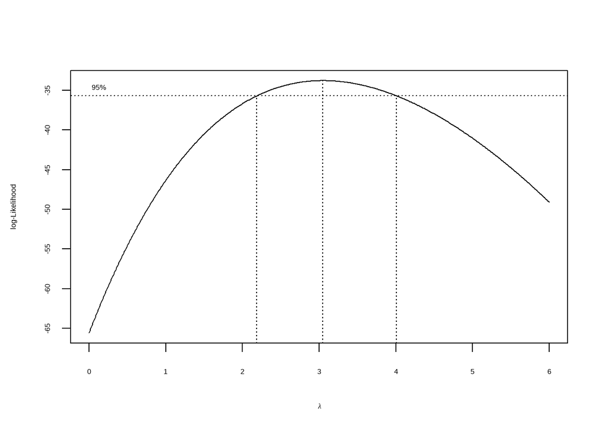

```r
index <- seq_len(nrow(subset_data))

# Box-Cox
bc1 <- boxcox(
  subset_data[[target_col]] ~ index,
  lambda = seq(0, 6, by = 0.01)
)
```

```r
# Nilai lambda optimum
lambda_bc1 <- bc1$x[which.max(bc1$y)]
lambda_bc1
```

```
## [1] 3.05
```

```r
# Selang kepercayaan 95% untuk lambda
ci_lambda1 <- bc1$x[bc1$y > max(bc1$y) - 0.5 * qchisq(0.95, 1)]

# Batas bawah dan batas atas
ci_lower1 <- min(ci_lambda1)
ci_upper1 <- max(ci_lambda1)

c(Batas_Bawah = ci_lower1, Batas_Atas = ci_upper1)
```

```
## Batas_Bawah  Batas_Atas
##        2.19        4.00
```

Hasil uji Box–Cox menunjukkan bahwa nilai λ optimum adalah 3.05 dengan interval kepercayaan 95% sebesar (2.19–4.00). Karena selang tersebut tidak memuat nilai λ = 1, maka dapat disimpulkan bahwa data tidak stasioner dalam ragam sehingga diperlukan transformasi.

# 4 Penanganan Stasioneritas Ragam

## 4.1 Transformasi Box–Cox

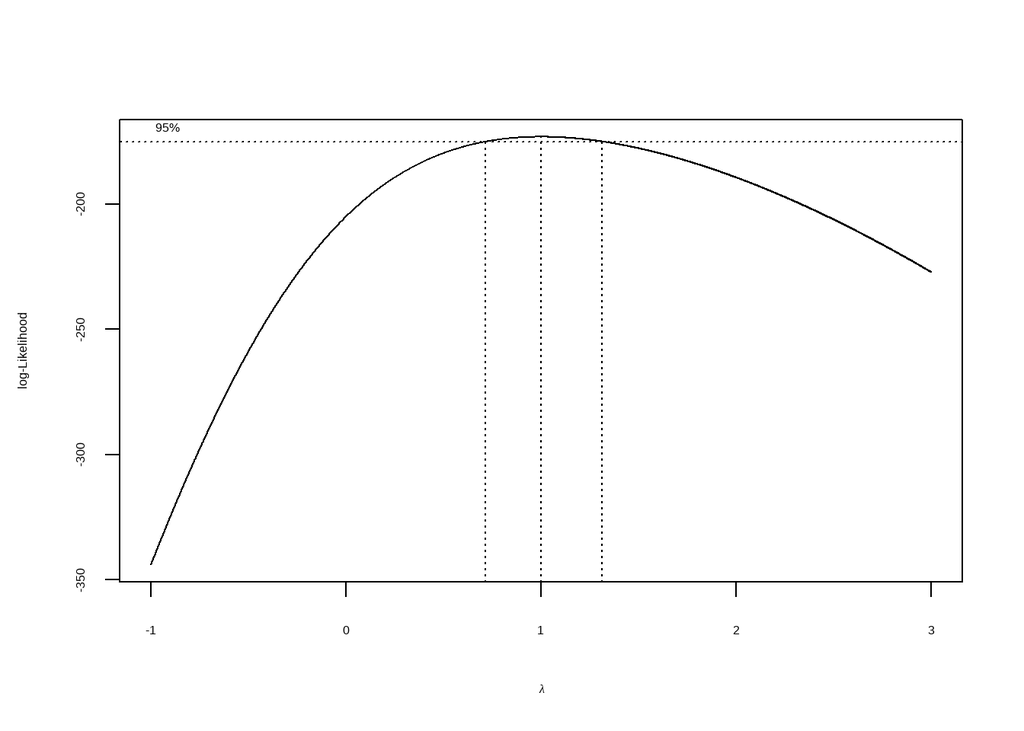

```r
# Transformasi Box-Cox dengan lambda ~ 3.05
y_bc2 <- subset_data[[target_col]]^lambda_bc1

# Uji Box-Cox
bc2 <- boxcox(
  y_bc2 ~ index,
  lambda = seq(-1, 3, by = 0.001)
)
```

```r
# Nilai lambda optimum (dibulatkan)
lambda_bc2 <- bc2$x[which.max(bc2$y)]
lambda_bc2
```

```
## [1] 1
```

```r
# Selang kepercayaan 95% untuk lambda
ci_lambda2 <- bc2$x[bc2$y > max(bc2$y) - 0.5 * qchisq(0.95, 1)]

# Batas bawah dan batas atas
ci_lower2 <- min(ci_lambda2)
ci_upper2 <- max(ci_lambda2)

c(Batas_Bawah = ci_lower2, Batas_Atas = ci_upper2)
```

```
## Batas_Bawah  Batas_Atas
##       0.716       1.314
```

Hasil uji Box–Cox menunjukkan bahwa nilai λ optimum adalah 1 dengan interval kepercayaan 95% sebesar (0.716–1.314). Karena selang tersebut memuat nilai λ = 1, maka dapat disimpulkan bahwa data stasioner dalam ragam.

# 5 Perbandingan Plot Sebelum Vs Sesudah Box-Cox

## 5.1 Plot *Time Series*

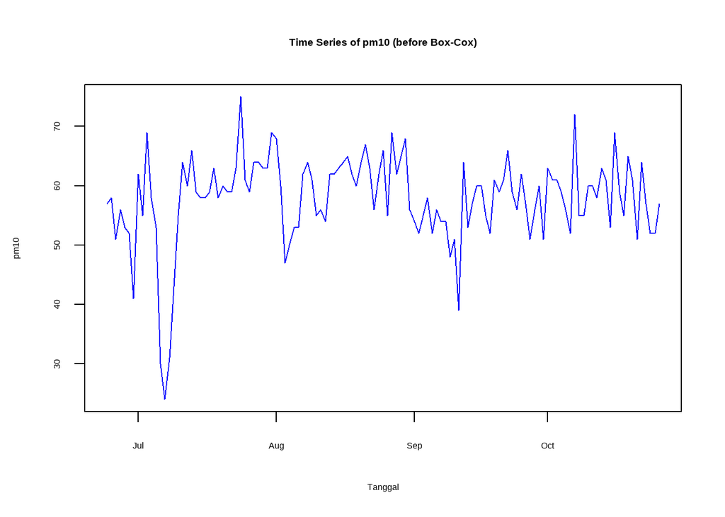

```r
# Time Series sebelum Box–Cox
plot(subset_data$tanggal, subset_data[[target_col]], type="l",
     main=paste("Time Series of", target_col, "(before Box-Cox)"),
     xlab="Tanggal", ylab=target_col, col="blue")
```

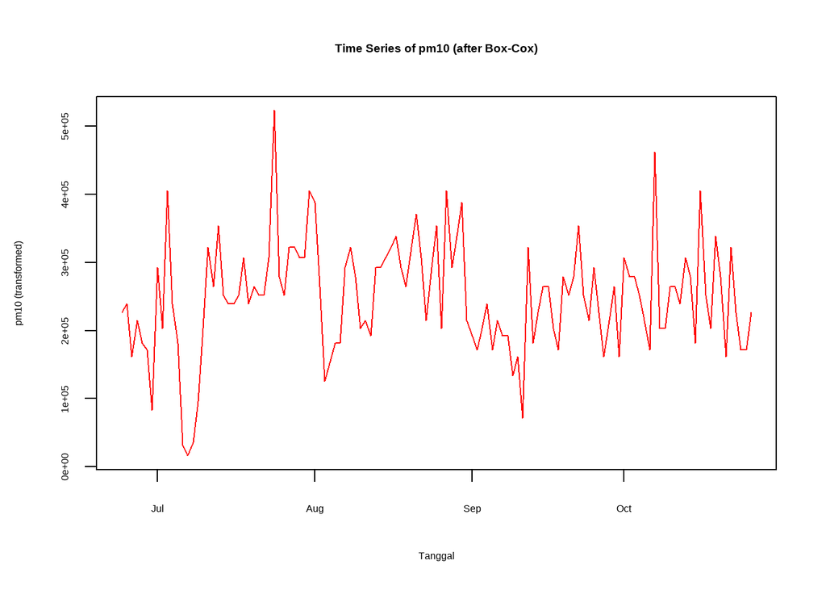

```r
# Time Series sesudah Box–Cox
plot(subset_data$tanggal, y_bc2, type="l",
     main=paste("Time Series of", target_col, "(after Box-Cox)"),
     xlab="Tanggal", ylab=paste(target_col, "(transformed)"), col="red")
```

Berdasarkan plot *time series*, data terlihat stasioner dalam rataan karena tidak menunjukkan adanya tren maupun pola musiman dan data juga terlihat stasioner dalam ragam, ditandai dengan data berfluktuasi pada rentang yang relatif sama sepanjang waktu.

```r
mean(subset_data[[target_col]])
```

```
## [1] 57.84
```

## 5.2 Plot *Density*

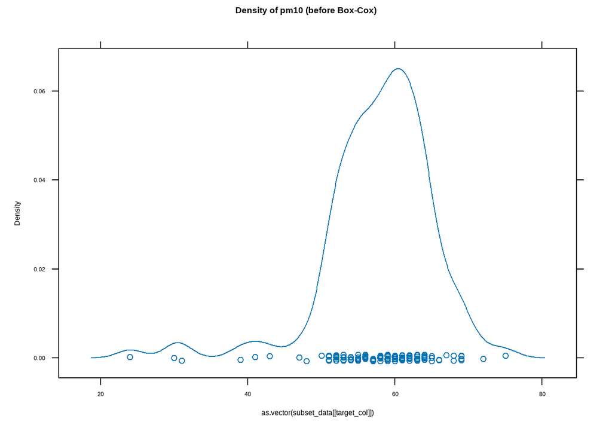

```r
# Density sebelum Box–Cox
lattice::densityplot(as.vector(subset_data[[target_col]]),
                     main = paste("Density of", target_col, "(before Box-Cox)"))
```

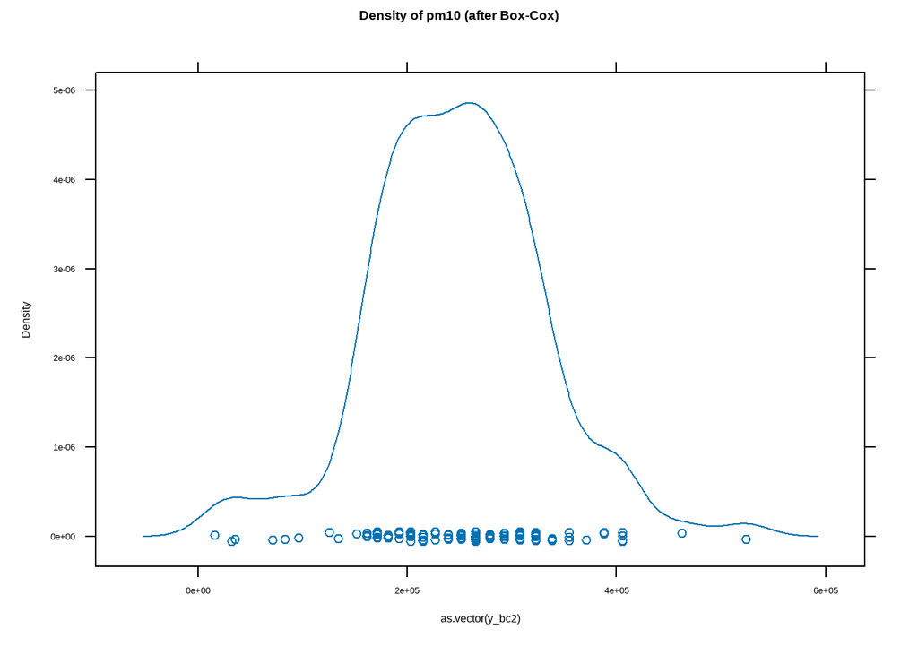

```r
# Density sesudah Box–Cox
lattice::densityplot(as.vector(y_bc2),
                     main = paste("Density of", target_col, "(after Box-Cox)"))
```